# Commits github

Ivyna Santino

9 de julho de 2018

Para este checkpoint, iremos utilizar uma base de dados do github, onde iremos trabalhar com a quantidade de commits que cada linguagem recebeu na plataforma. Então, primeiramente iremos importar os dados:

```r
commits = read_csv(here("data/github-users-committing-filetypes.csv"))
```

Ao importar o csv, notei que na base de dados não fornecia os dias da semana, mas somente a data. Dessa forma, será necessário descobrir qual o dia equivalente para essas datas, com o objetivo de facilitar nosso trabalho e responder as questões propostas abaixo.

```r
commits <- commits %>%
  mutate(date = paste(the_year,the_month,month_day,sep='-') %>%
           as.Date(.))

commits$weekday <- weekdays(as.Date(commits$date))

commits <- commits %>%
  mutate(is_weekend = ifelse(weekday %in% c("sábado","domingo"),TRUE,FALSE))

dados_filtrados <- commits %>%
  filter(file_extension %in% c("js","py"))
```

Outra informação relevante é foi a escolha das linguagens para análise, sendo elas: javascript e python, representadas respectivamente como js e py.

Dessa forma, iremos fazer uma breve observação com os dados que temos em mãos. Para isso, filtrei os commits pelos anos(2017 e 2016) de forma que, ficassem em gráficos separados e permitir a comparação entre as duas linguagens de maneira mais intuitiva.

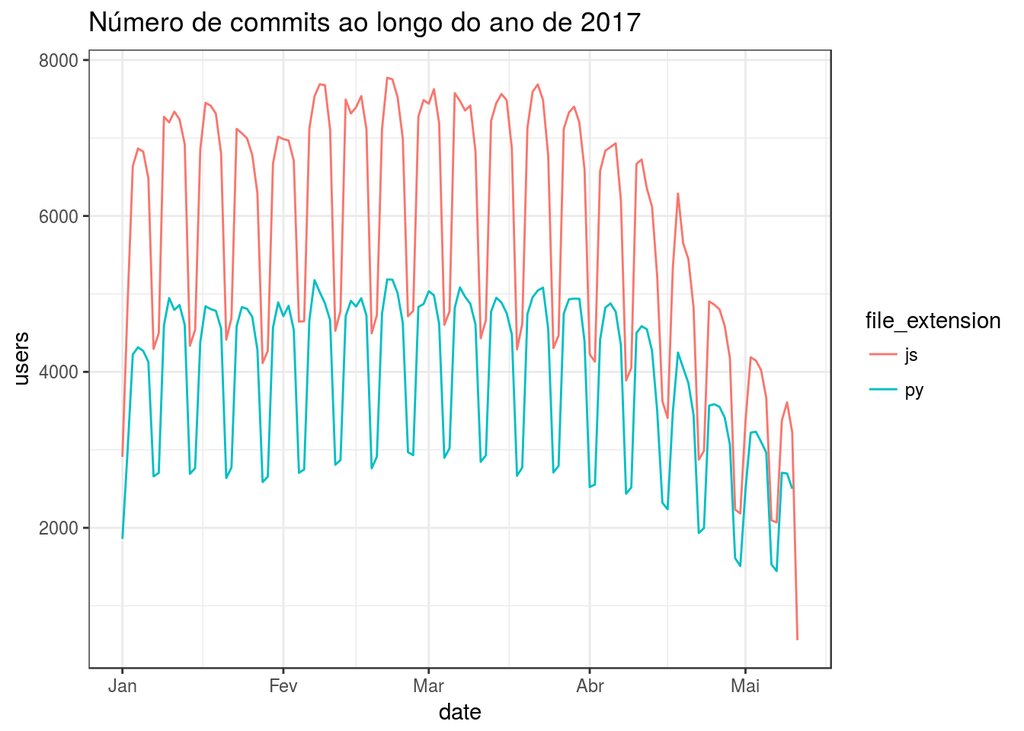

```r
dados_filtrados %>%
  filter(the_year == 2017) %>%
  ggplot(aes(x = date,
             y = users,
             color = file_extension)) +
  geom_line() +
  labs(title = "Número de commits ao longo do ano de 2017")
```

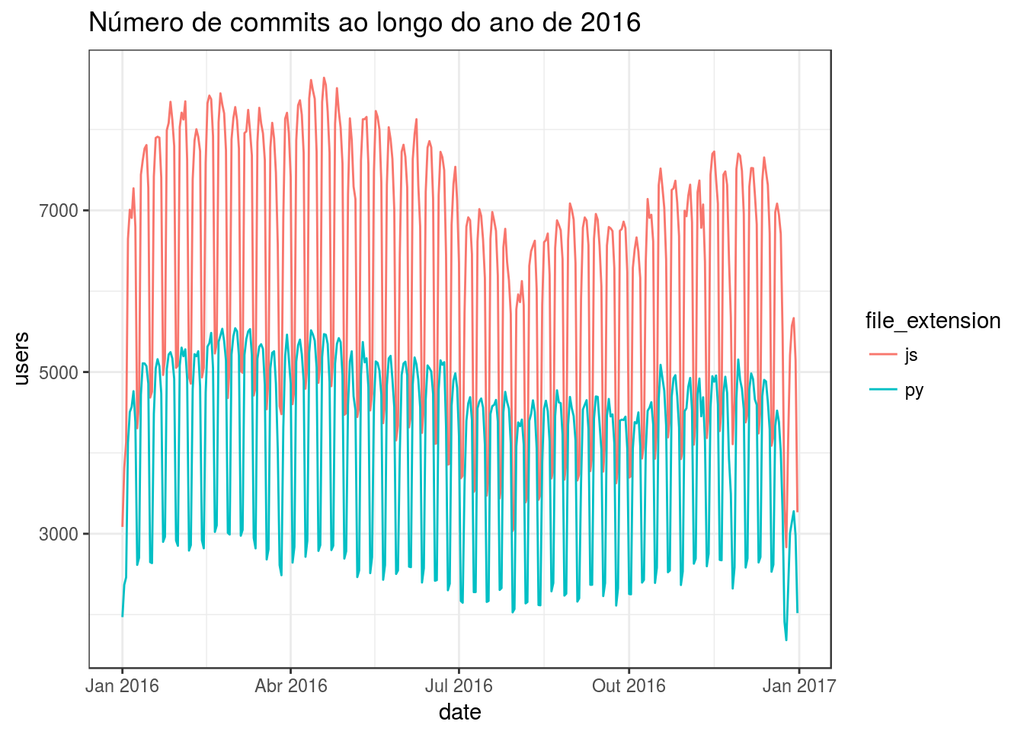

```r
dados_filtrados %>%
  filter(the_year == 2016) %>%
  ggplot(aes(x = date,
             y = users,
             color = file_extension)) +
  geom_line() +
  labs(title = "Número de commits ao longo do ano de 2016")
```

### Então, demonstrados os dados que iremos trabalhar, podemos dizer que para cada uma das linguagens, há uma diferença significativa na sua popularidade durante a semana e durante o fim de semana? Essa diferença é grande?

Antes de mostrar os gráficos, iremos tratar os dados afim de melhorar a visualização separando os dias úteis e finais de semana para cada linguagem.

```r
dados_js = dados_filtrados %>%
  select(file_extension, users, weekday, is_weekend) %>%
  filter(file_extension == "js")

js_fds = dados_js %>%
  filter(is_weekend == TRUE)

js_util = dados_js %>%
  filter(is_weekend == FALSE)


dados_py = dados_filtrados %>%
  select(file_extension, users, weekday, is_weekend) %>%
  filter(file_extension == "py")

py_fds = dados_py %>%
  filter(is_weekend == TRUE)

py_util = dados_py %>%
  filter(is_weekend == FALSE)
```

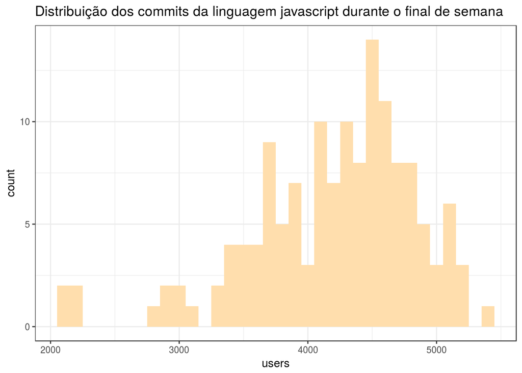

```r
js_fds %>%
  ggplot(aes(x = users)) +
  geom_histogram(binwidth = 100,
                 fill = "#FFDEAD") +
  labs(title = "Distribuição dos commits da linguagem javascript durante o final de semana")
```

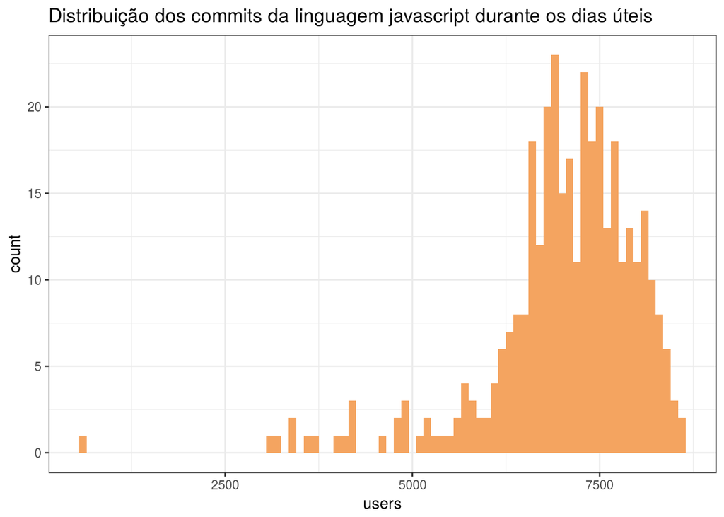

```r
js_util %>%
  ggplot(aes(x = users)) +
  geom_histogram(binwidth = 100,
                 fill = "#F4A460") +
  labs(title = "Distribuição dos commits da linguagem javascript durante os dias úteis")
```

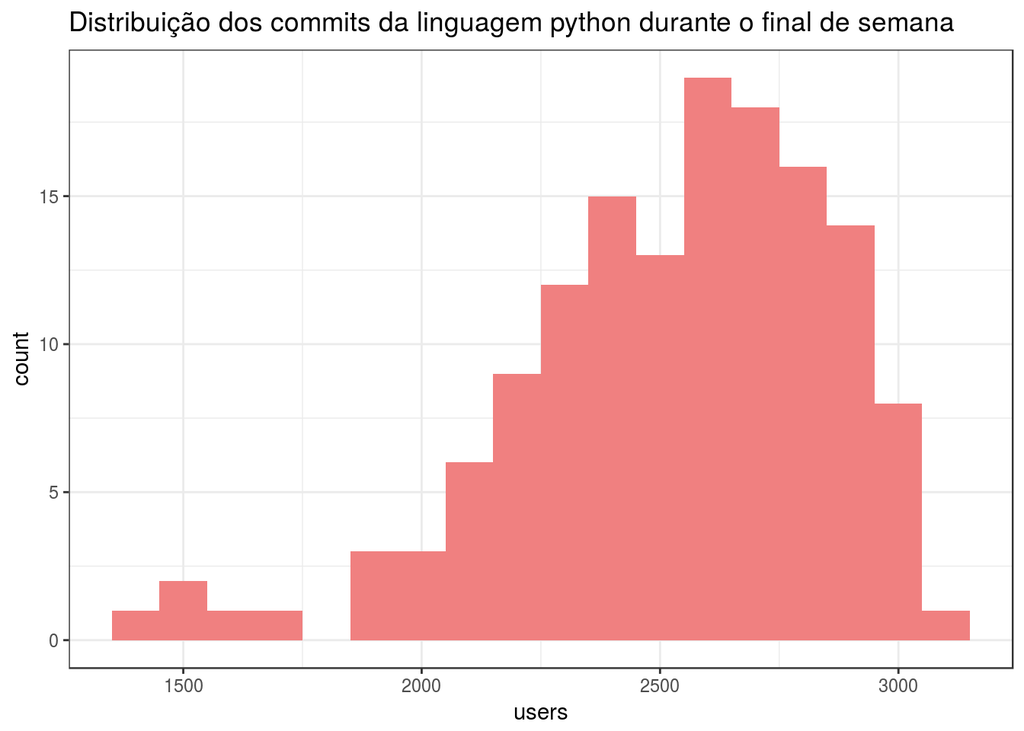

```r
py_fds %>%
  ggplot(aes(x = users))+
  geom_histogram(binwidth = 100,
                 fill = "#F08080") +
  labs(title = "Distribuição dos commits da linguagem python durante o final de semana")
```

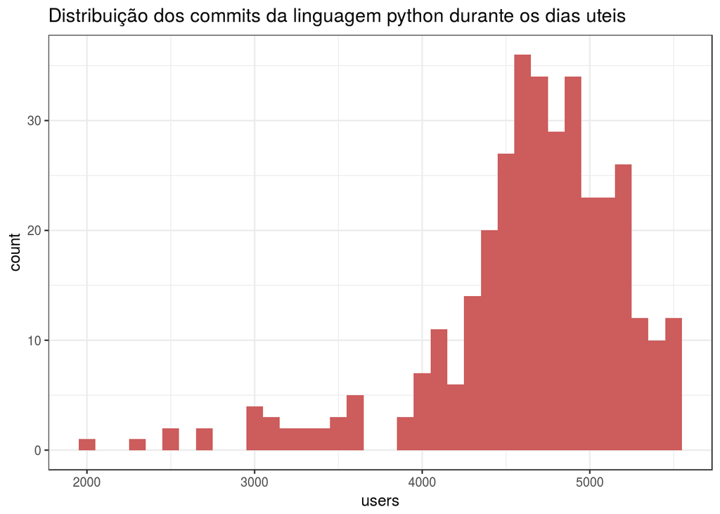

```r
py_util %>%
  ggplot(aes(x = users))+
  geom_histogram(binwidth = 100,
                 fill = "#CD5C5C") +
  labs(title = "Distribuição dos commits da linguagem python durante os dias uteis")
```

```r
amostra_js_fds <- sample_n(js_fds, 100)
colnames(amostra_js_fds) <- c("file_extension","users_js_fds","is_weekend")
amostra_js_util <- sample_n(js_util, 100)
colnames(amostra_js_util) <- c("file_extension","users_js_util","is_weekend")

b <- bootstrap(amostra_js_fds, mean(users_js_fds))
media_js_fds <- CI.bca(b, probs = c(.025, .975))
media_js_fds
```

```
##                        2.5%    97.5%
## mean(users_js_fds) 4065.462 4329.972
```

```r
b <- bootstrap(amostra_js_util, mean(users_js_util))
media_js_util <- CI.bca(b, probs = c(.025, .975))
media_js_util
```

```
##                         2.5%   97.5%
## mean(users_js_util) 6854.112 7283.59
```

```r
amostra_py_fds <- sample_n(py_fds, 100)
colnames(amostra_py_fds) <- c("file_extension","users_py_fds","is_weekend")
amostra_py_util <- sample_n(py_util, 100)
colnames(amostra_py_util) <- c("file_extension","users_py_sem","is_weekend")

b <- bootstrap(amostra_py_fds, mean(users_py_fds))
media_py_fds <- CI.bca(b, probs = c(.025, .975))
media_py_fds
```

```
##                        2.5%    97.5%
## mean(users_py_fds) 2461.451 2592.556
```

```r
b <- bootstrap(amostra_py_util, mean(users_py_sem))
media_py_util <- CI.bca(b, probs = c(.025, .975))
media_py_util
```

```
##                        2.5%    97.5%
## mean(users_py_sem) 4589.445 4808.173
```

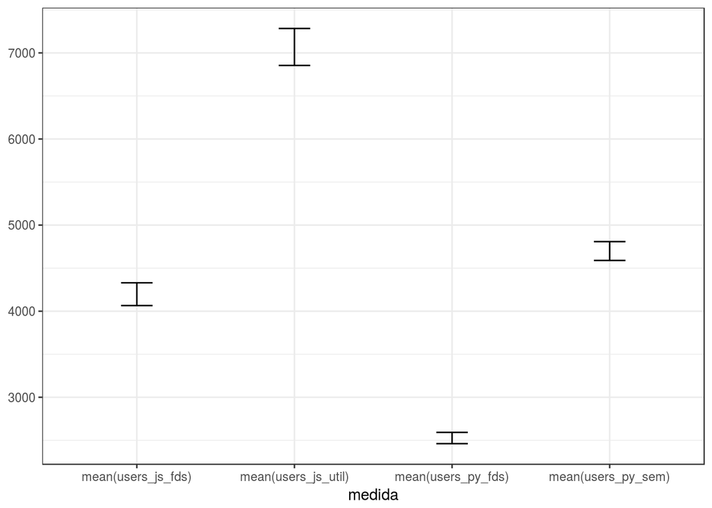

```r
df = data.frame(rbind(media_js_fds,
                      media_js_util,
                      media_py_fds,
                      media_py_util))
df$medida = row.names(df)

df %>%
  ggplot(aes(x = medida, ymin = X2.5., ymax = X97.5.)) +
  geom_errorbar(width = .2)
```

A partir desse gráfico, podemos observar que os intervalos são bem pequenos e os que estão mais próximos são javascript quando usado no final de semana e python quando usado dia de semana. E, algo que também se destaca é com relação a linguagem javascript, possuindo o maior intervalo e na sua utilização nos dias úteis. Sendo assim, é visível que as linguagens trabalhadas são mais utilizadas nos dias úteis.

### Outro questionamento, existe uma diferença significativa entre a popularidade das duas linguagens nos fins de semana?

Para responder essa questão, iremos calcular o desvio padrão das linguagens no final de semana.

```r
b <- bootstrap(amostra_js_fds, sd(users_js_fds))
sd_js_fds <- CI.bca(b, probs = c(.025, .975))
sd_js_fds
```

```
##                      2.5%    97.5%
## sd(users_js_fds) 568.6591 810.5051
```

```r
b <- bootstrap(amostra_py_fds, sd(users_py_fds))
sd_py_fds <- CI.bca(b, probs = c(.025, .975))
sd_py_fds
```

```
##                      2.5%    97.5%
## sd(users_py_fds) 290.2553 397.4321
```

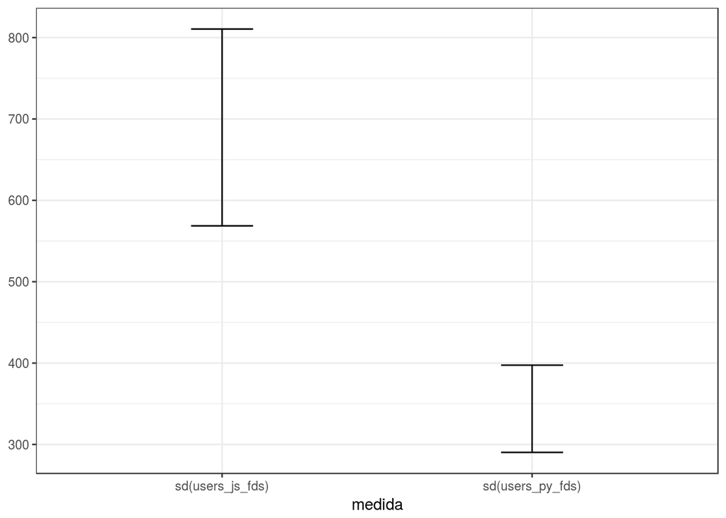

```r
df = data.frame(rbind(sd_js_fds,
                      sd_py_fds))
df$medida = row.names(df)

df %>%
  ggplot(aes(x = medida, ymin = X2.5., ymax = X97.5.)) +
  geom_errorbar(width = .2)
```